# 36-315 Homework 08, Fall 2019

Eu Jing Chua

Due Wed, Nov 6 2019 (11:00pm ET) on Canvas

## Homework 08

*General instructions for all assignments*:

- Use this file as the template for your submission. Delete the unnecessary text (e.g. this text, the problem statements, etc). That said, keep the nicely formatted “Problem 1”, “Problem 2”, “a.”, “b.”, etc
- Upload a single `R` Markdown file (named as: [AndrewID]-315-HW08.Rmd – e.g. “mneykov-315-HW08.Rmd”) to the Homework 08 submission section on Canvas. You do not need to upload the .html file.
- The instructor and TAs will run your .Rmd file on their computers. **If your .Rmd file does not knit on our computers, you will automatically get 0 points.**
- Your file should contain the code to answer each question in its own code block. Your code should produce plots/output that will be automatically embedded in the output (.html) file
- Each answer must be supported by written statements (unless otherwise specified)
- Include the name of anyone you collaborated with at the top of the assignment
- Include the style guide you used below under Problem 0

# Problem 0

**Organization, Themes, and HTML Output**

(5 points)

1. For all problems in this assignment, organize your output as follows:
- Use code folding for all code. See [here](http://blog.rstudio.org/2016/03/21/rmarkdown-v0-9-5/) for how to do this.
- Use a floating table of contents.
- Suppress all warning messages in your output by using `warning = FALSE` and `message = FALSE` in every code block.
- Use tabs only if you see it fit to do so – this is your choice.
2. For all problems in this assignment, adhere to the following guidelines for your `ggplot` theme and use of color:
- Do not use the default `ggplot()` color scheme.
- For any bar chart or histogram, outline the bars (e.g. with `color = "black"`).
- Do not use both red and green in the same plot, since a large proportion of the population is red-green colorblind.
- Try to only use three colors (at most) in your themes. In previous assignments, many students are using different colors for the axes, axis ticks, axis labels, graph titles, grid lines, background, etc. This is unnecessary and only serves to make your graphs more difficult to read. Use a more concise color scheme.
- Make sure you use a white or gray background (preferably light gray if you use gray).
- Make sure that titles, labels, and axes are in dark colors, so that they contrast well with the light colored background.
- Only use color when necessary and when it enhances your graph. For example, if you have a univariate bar chart, there’s no need to color the bars different colors, since this is redundant.
- In general, try to keep your themes (and written answers) professional. Remember, you should treat these assignments as professional reports.
3. Treat your submission as a formal report:
- Use complete sentences when answering questions.
- Answer in the context of the problem.
- Treat your submission more as a formal “report”, where you are providing details analyses to answer the research questions asked in the problems.
4. What style guide are you using for this assignment?

Using the tidyverse style guide.

```r
knitr::opts_chunk$set(warning = FALSE, message = FALSE)
```

```r
library(tidyverse)
library(viridis)

eujingc_315_theme <-  theme_bw() +
  theme(axis.text = element_text(size = 12),
        plot.title = element_text(size = 20, face = "bold", hjust = 0),
        plot.subtitle = element_text(size = 14, face = "italic", hjust = 0),
        text = element_text(size = 14, face = "bold", color = "darkslategrey"))
```

# Problem 1

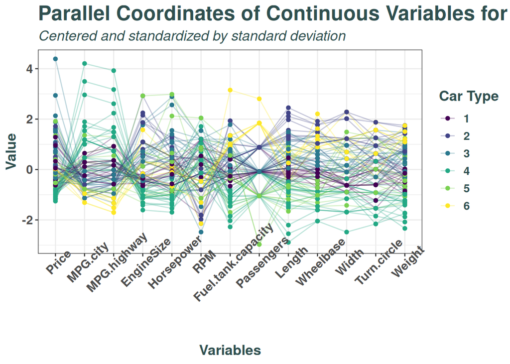

```r
library(MASS)
library(tidyverse)
library(GGally)
data(Cars93)
cont_cols <- which(names(Cars93) %in%
                     c("Cars93", "Price", "MPG.city",
                       "MPG.highway", "EngineSize",
                       "Horsepower", "RPM", "Fuel.tank.capacity", "Passengers",
                       "Length", "Wheelbase", "Width", "Turn.circle", "Weight"))

ggparcoord(Cars93, columns = cont_cols, showPoints = TRUE, alphaLines = 0.3) +
    aes(color = factor(Type)) +
    labs(color = "Car Type", x = "Variables", y = "Value",
         title = "Parallel Coordinates of Continuous Variables for Cars",
          subtitle = "Centered and standardized by standard deviation") +
    scale_color_viridis(discrete = TRUE) +
    eujingc_315_theme +
    theme(axis.text.x = element_text(angle = 45))
```

2. Each line in the plot corresponds to an observation in our data, with the x-axis corresponding to each continuous variable and the y-axis corresponding to the standardized score of the continuous variable for each observation.

   We can see that cars of type 4 tend to have higher mileage than the other types, while cars of type 6 tend to accomodate more passengers.
3. The parallel coordinates plot is easier to read as we can follow each line that corresponds to each observation more easily.

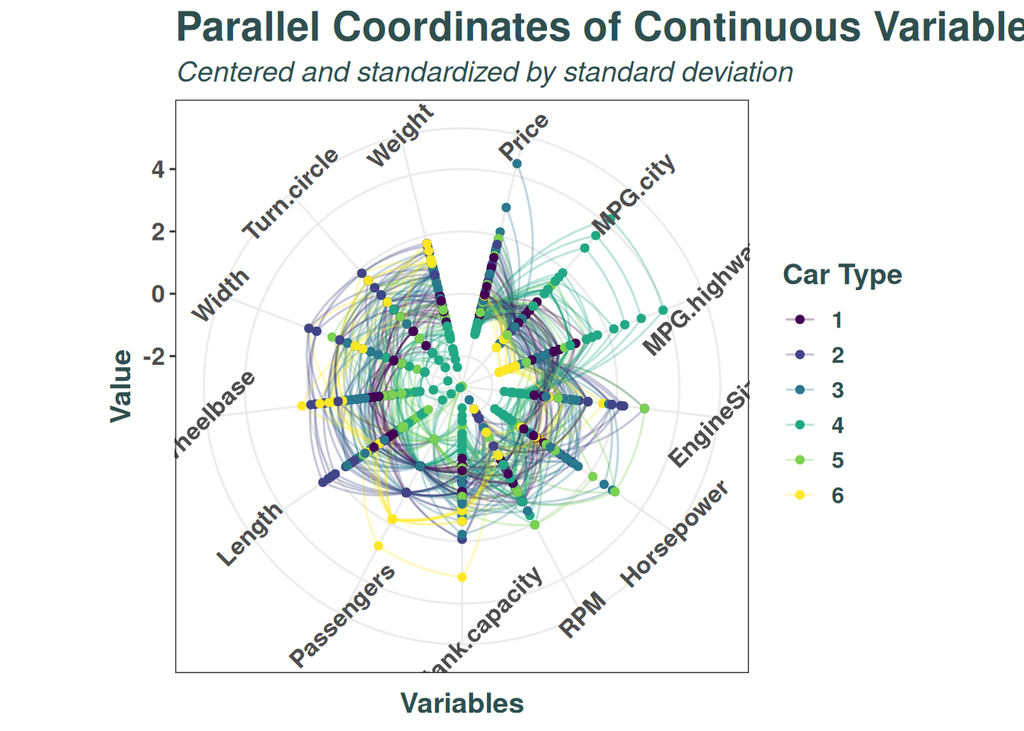

```r
ggparcoord(Cars93, columns = cont_cols, showPoints = TRUE, alphaLines = 0.3) +
    aes(color = factor(Type)) +
    coord_polar() +
    labs(color = "Car Type", x = "Variables", y = "Value",
         title = "Parallel Coordinates of Continuous Variables for Cars",
          subtitle = "Centered and standardized by standard deviation") +
    scale_color_viridis(discrete = TRUE) +
    eujingc_315_theme +
    theme(axis.text.x = element_text(angle = 45))
```

4. The default y-axis is centered and standardized by standard deviation. We can use `scale = "center"`.

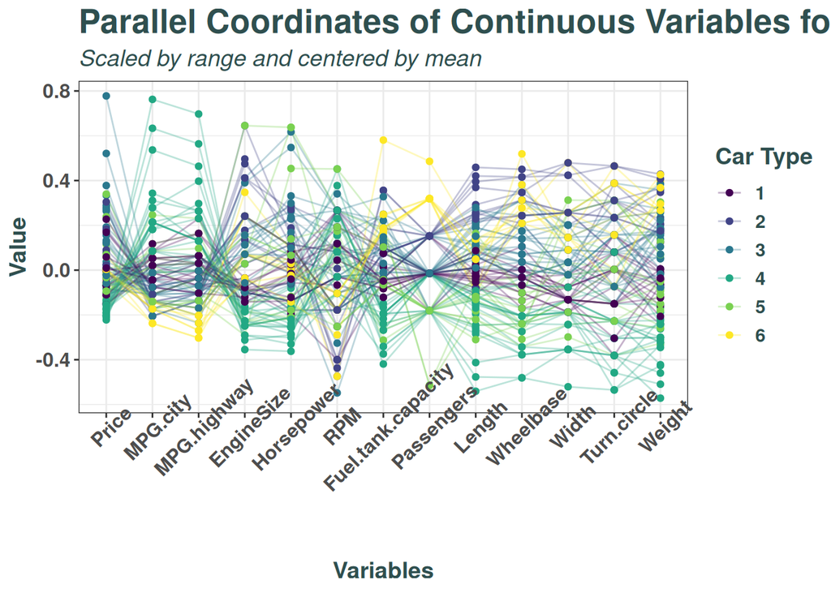

```r
ggparcoord(Cars93, columns = cont_cols, showPoints = TRUE, alphaLines = 0.3,
           scale = "center") +
    aes(color = factor(Type)) +
    labs(color = "Car Type", x = "Variables", y = "Value",
         title = "Parallel Coordinates of Continuous Variables for Cars",
          subtitle = "Scaled by range and centered by mean") +
    scale_color_viridis(discrete = TRUE) +
    eujingc_315_theme +
    theme(axis.text.x = element_text(angle = 45))
```

5. City mileage is positively correlated with highway mileage. We can see how cars with high city mileage with positive scaled values corresponding with high highway mileage with positive scaled values too.

   The highway mileage is negatively correlated with the engine size. We can see how cars with high mileage having positive scaled values have negative scaled values for engine size.

# Problem 2

(18 points)

**Correlation Matrices for Examining Variable Relationships**

We’ve covered a few ways to visualize datasets that have many continuous variables (e.g. dimension reduction via multi-dimensional scaling, dendrograms, parallel coordinates plots, etc). Another option is a correlation heat map.

A correlation heat map provides a quick visualization of the bivariate correlations between all pairs of continuous variables in the dataset.

1. (0 points) Code is provided for you to do the following tasks:
- Load the `Cars93` dataset
- Create a subset with only the continuous variables

```r
cars_cont <- dplyr::select(Cars93, Price, MPG.city, MPG.highway, EngineSize,
                           Horsepower, RPM, Fuel.tank.capacity, Passengers,
                           Length, Wheelbase, Width, Turn.circle, Weight)
```

2. (5 points) Partial code is provided for you to do the following tasks:
- Follow the example [here](http://www.sthda.com/english/wiki/ggplot2-quick-correlation-matrix-heatmap-r-software-and-data-visualization) to create a correlation heap map of the continuous variables in the `Cars93` dataset
- Adjust the color scheme so that correlations of -1 is shown in dark red, a correlation of 0 is shown in light grey, and a correlation of 1 is shown in dark blue. **To get the correct range/ `limits` you may which to also look at `?continuous_scale`.**
- Rotate the x-axis tickmark label 90 degrees
- Add a title and adjust all axis and legend labels appropriately.

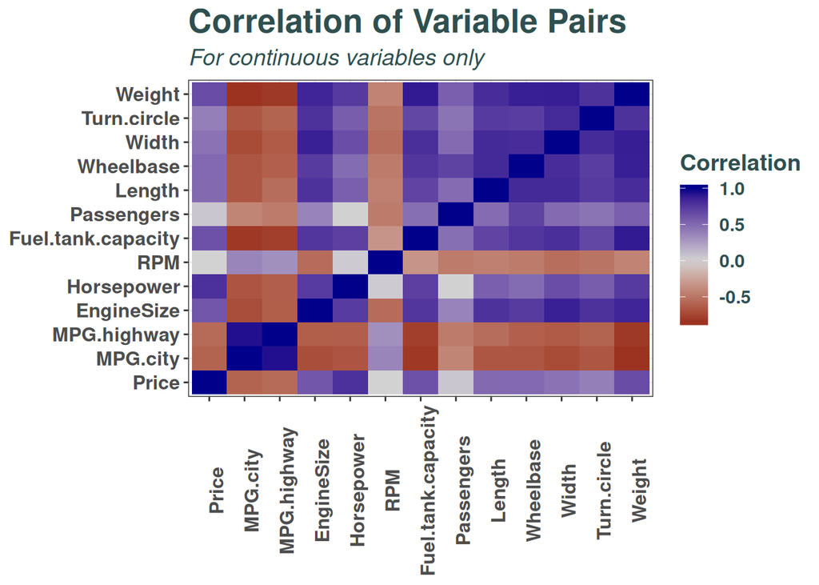

```r
library(reshape2)
correlation_matrix <- cor(cars_cont)
melted_cormat <- melt(correlation_matrix)
ggplot(data = melted_cormat, aes(x = Var1, y = Var2, fill = value)) +
  geom_tile() +
  scale_fill_gradient2(low = "darkred", mid = "lightgrey", high = "darkblue") +
  labs(title = "Correlation of Variable Pairs",
       subtitle = "For continuous variables only",
       fill = "Correlation") +
  eujingc_315_theme +
  theme(axis.text.x = element_text(angle = 90),
        axis.title.x = element_blank(), axis.title.y = element_blank())
```

3. (5 points) Interpret the resulting graph:
- Which pairs of variables are highly positively correlated?
- Which are highly negatively correlated?
- Which have approximately no correlation?
4. (2 points) Explain the connection between this plot and a heat map.
5. (1 point) Even though they are very different, what plot for examining the associations between categories of two categorical variables does this remind you of?
6. (5 points) Recreate the graph in (b), making the following additional adjustments to the correlation matrix:
- Reorder the variables as you see fit
- Add the correlation rounded to 2 decimal (eg. .98) to the plot via `geom_text()`
- Only display the upper or lower triangle of the graph *(hint `lower.tri` or `upper.tri` might be something useful)*.

# Problem 3

(20 points)

**Variable Dendrograms**

Another way to visually explore potential associations between continuous variables in our dataset is with dendrograms.  
But we will compute a dendogram on features instead of data points. In other words, we cluster vraiables rather than cars.

1. (15 points) Create a “variable dendrogram” of the continuous variables in the `Cars93` dataset. To do this:
- Select the continuous variables from the dataset
- Compute the correlation matrix for these variables
- Correlations measure similarity and can be negative, while distances measure dissimilarity and cannot be negative. As such, convert your correlations to instead be one minus the absolute value of the correlations, so that correlations near 1 or -1 will have distances of 0, and correlations near 0 will have distances of 1, e.g.: `cormat <- 1 - abs(cormat)`
- Convert your transformed correlation matrix to a distance matrix with the `as.dist()` function.
- Submit this distance matrix to hierarchical clustering (`hclust()`), convert the result to a dendrogram (`as.dendrogram()`), then plot with `ggplot()`.
- Color the branches by the four-cluster solution. See the link in HW07 for how to do this.
- Be sure to adjust your axis labels, add a title, etc.
- The resulting dendrogram should plot highly correlated variables (positively or negatively correlated) in the same branches / clusters in the dendrogram, while uncorrelated variables will be linked at higher “distances” on the dendrogram.
2. (5 points) Examine the four-cluster solution. Which variables are in the same cluster? Does it make sense that these are in the same cluster, given both your common-sense understanding of these variables and given the correlation plot you created in Problem 2?
3. (1 point) What other measures (other than correlation) could you use to measure similarity / dissimilarity between continuous variables for the purposes of a variable dendrogram? (There is not necessarily a right or wrong answer here – just brainstorm ideas.)

**If you’re finding your graphic runs over the boundaries, try standard approaches of `ylim` and `xlim` changes. Additionally, sometimes the knitted file looks different - knit once before you run.**

# Problem 4

Use this command

g = barabasi.game(1000,power=1,directed=FALSE)

to create a random graph that is similar to some real social networks.

1. (2 points) Plot the graph using the plot command in igraph. Try different layouts and try adjusting the parameters of the plot until you get a nice plot. Use help(plot.igraph) to see the options. Your homework should only include one graph.
2. (2 points) Now plot the graph using ggraph. Again, choose the options carefully.
3. (2 points) Compute and report the key summary statistics of the graph.
4. (6 points) Try two different igraph clustering algorithms. Explain what they are doing. Show the resulting plots and say what the modularity is. Which algorithm do you think worked better and why?
5. (2 points) Draw a histogram of betweeness(g). What is the interpretation of this?

# Problem 5

Load the iris data. Define

X = log(iris[,1:4])

1. (2 points) Use out = prcomp(X,center=TRUE,scale=TRUE) to perform a principal components analysis. What do the options center=TRUE and scale=TRUE do?
2. (2 points) Plot the output using the biplot command. Interpret the output.
3. (2 points) Now plot the projection onto the first two principal components by plotting the first two columns of out$x. Add colors corresponding two the species. Do the principal components separate the species well?
4. (4 points) Repeat the analysis using kernel pca. I suggest using the kpca functiuon in the kernlab library.
5. (2 points) Now repeat the analysis using tsne. Try perplexity = 30 and perplexity = 5. What happens as you change the perplexity?
6. (2 points) Load the mlbench library and use this command:

X = 4*mlbench.spirals(100,1,.025)$x

Plot the data.

7. (4 points) Use the command

sc = specc(X, centers=2)

from kernlab to perform spectral clustering. Plot the data and use two colors to indicate the result of the spectral clustering. Now repeat using kmeans clustering. Why did the spectral clustering work better?

# Problem 6

(1 point each)

**Arc Pie Charts**

Install and load the `ggforce` package. This package implements several updates and improvements to `ggplot2`.

1. Create an “arc pie chart” of the `Type` variable in the `Cars93` dataset. (Code provided.)

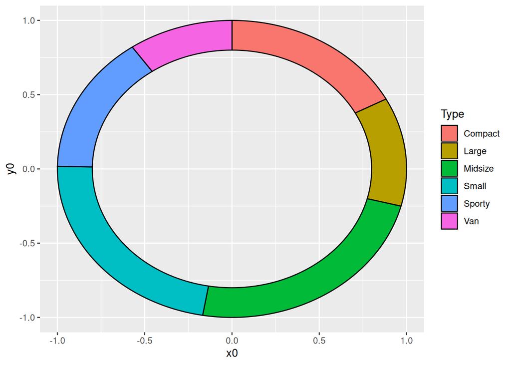

```r
library(ggforce)
Cars93 %>% group_by(Type) %>%
  summarize(count = n()) %>%
  mutate(max = max(count),
         focus_var = 0.2 * (count == max(count))) %>%
  ggplot() + geom_arc_bar(aes(x0 = 0, y0 = 0, r0 = 0.8, r = 1,
                              fill = Type, amount = count),
                          stat = 'pie')
```

2. Adjust the `r0` parameter to lower and higher values. What does this control? What is the minimum and maximum value?
3. Recreate the graph from (a), but this time, add `explode = focus_var` into your call to `aes()`. What does this do?
4. Recreate the graph from (c), but this time, add focus to the category with the minimum number of observations.
5. Critique these graphs.

# Problem 7

(5 points each)

**Zoom**

See the following code working with the IMDb movies dataset for how to use `facet_zoom()`.

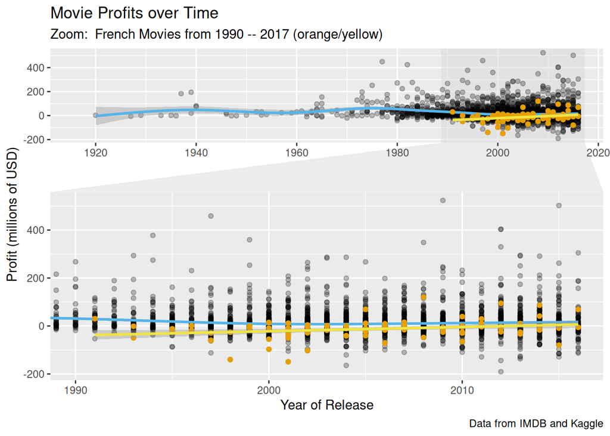

```r
library(tidyverse)
library(forcats)
library(devtools)
library(ggforce)

#  Colorblind-friendly color pallette
my_colors <- c("#000000", "#56B4E9", "#E69F00", "#F0E442", "#009E73", "#0072B2",
               "#D55E00", "#CC7947")

#  Read in the data
imdb <- read_csv("https://raw.githubusercontent.com/mateyneykov/315_code_data/master/data/imdb_test.csv")

# get some more variables
imdb <- mutate(imdb, profit = (gross - budget) / 1000000,
               is_french = ifelse(country == "France", "Yes", "No")) %>%
  filter(movie_title != "The Messenger: The Story of Joan of Arc")
france_1990 <- filter(imdb, country == "France", title_year >= 1990)

# this code plots a scatterplot + a zoomed facet
ggplot(data = imdb, aes(x = title_year, y = profit)) +
  geom_point(color = my_colors[1], alpha = 0.25) +
  geom_smooth(color = my_colors[2]) +
  geom_point(data = france_1990, color = my_colors[3]) +
  geom_smooth(data = france_1990, aes(x = title_year, y = profit),
              color = my_colors[4], method = lm) +
  facet_zoom(x = title_year >= 1990) +
  labs(title = "Movie Profits over Time",
       subtitle = "Zoom:  French Movies from 1990 -- 2017 (orange/yellow)",
       caption = "Data from IMDB and Kaggle",
       x = "Year of Release",
       y = "Profit (millions of USD)")
```

Also read the articles [here](https://www.r-bloggers.com/announcing-ggforce-accelerating-ggplot2/), or [here](https://cran.r-project.org/web/packages/ggforce/vignettes/Visual_Guide.html#b-splines).

1. Recreate any scatterplot that we created throughout the year, and zoom in on a section of the graph via the `facet_zoom()` feature in the newest version of the `ggforce` package. Include a title, subtitle, and caption in the resulting graph. The caption should just state the data source, and the subtitle should explain what area of the plot is being enhanced via zooming.
2. Interpret the resulting graph: Describe some feature of the new version of the graph that you may not have been able to see very well in the previous version of the same graph (without zooming).